# Modern Portfolio Theory

```python
from IPython.display import display, HTML

display(HTML('''
    <style>
        /* Hide the input/output prompt area */
        div.prompt { display: none; }

        /* Make the notebook container full width */
        .container { width: 100% !important; margin-left: 0px !important; margin-right: 0px !important; }

        /* Adjust padding at the top */
        #notebook { padding-top: 0px !important; }

        /* Remove any end spacing */
        .end_space { min-height: 0px !important; }

        /* Remove borders for selected cells */
        div.cell.selected { border: None; }
    </style>
'''))

from IPython.display import display, HTML

display(HTML('''
    <style>
        /* Hide the input/output prompt area */
        div.prompt { display: none; }

        /* Make the notebook container full width */
        .container { width: 100% !important; margin-left: 0px !important; margin-right: 0px !important; }

        /* Adjust padding at the top */
        #notebook { padding-top: 0px !important; }

        /* Remove any end spacing */
        .end_space { min-height: 0px !important; }

        /* Remove borders for selected cells */
        div.cell.selected { border: None; }

        /* Increase the font size for Markdown cells */
        div.text_cell_render {
            font-size: 130% !important;
        }
    </style>
'''))
```

### **Modern Portfolio Theory (MPT) Overview**

[figure not shown]

##### Intro

- Question would you prefer portfolio A or portfolio B?
  - Modern Portfolio Theory provides an answer to this

##### Overview

- **Harry Markowitz**: Developed by economist Harry Markowitz in the 1950s for which he received Nobel Prize
- **Risk-return tradeoff**: Focuses on optimizing portfolio allocation by balancing risk and return.
- **Diversification**: The main idea behind MPT is diversification: by combining different assets, investors can reduce overall portfolio risk without sacrificing expected returns.

##### Risk-Averse Investor's Preference in MPT

**Assumptions**:

- **Risk Aversion**: Investors prefer less risk for the same or higher returns.
- **Return and Risk**: Let $\mu_A$ and $\sigma_A$ be the expected return and risk (standard deviation) of Portfolio A, and $\mu_B$ and $\sigma_B$ for Portfolio B. For a risk-averse investor, a higher return must not come with higher risk.
- **Preference Condition**:
- Suppose we have 2 portfolios A and B
- $\mu_A$ and $\mu_B$ are the expected returns for portfolios A and B respectively
- $\sigma_A$ and $\sigma_B$ are their expected risks (standard deviations) $$ \mu_A \geq \mu_B \iff \sigma_A \geq \sigma_B $$

This simple condition emphasizes that risk-averse investors are unwilling to trade off higher returns for higher risk, reinforcing the principles of portfolio optimization under MPT.

Key concepts in MPT include:

1. **Risk and Return Trade-off**:
   - MPT quantifies risk using the standard deviation of asset returns
   - Asserts that investors should seek portfolios that maximize expected return for a given level of risk or, conversely, minimize risk for a given level of return.
2. **Covariance/Correlation**: The relationship between the returns of different assets. Diversifying across assets with low or negative correlation can reduce overall portfolio risk.
3. **Portfolio Diversification**: By including a variety of uncorrelated or negatively correlated assets, investors can minimize the portfolio's overall risk. According to MPT, a diversified portfolio reduces unsystematic risk (risk specific to individual investments) while systematic risk (market-wide risk) remains.
4. **Efficient Frontier**: MPT suggests that, for a given level of risk, there exists an optimal set of portfolios that offer the highest expected return. These portfolios make up the **efficient frontier**, a curve that represents the most efficient risk-return combinations.

### Mathematical Formulation

To construct the efficient frontier in Markowitz's Modern Portfolio Theory (MPT), we typically use two equivalent optimization problem formulations:

1. **Minimizing Portfolio Variance for a Given Expected Return**
2. **Maximizing Expected Return for a Given Level of Risk**

Each point on the efficient frontier corresponds to a portfolio that has an optimal trade-off between risk and return.

Let’s define some key terms for these formulations:

- $S_1,\dots,S_n$: n assets
- $\mathbf{w} = [w_1, w_2, \dots, w_n]^\top$: The vector of portfolio weights for $n$ assets.
- $\mathbf{\mu} = [\mu_1, \mu_2, \dots, \mu_n]^\top$: The vector of expected returns for each asset.
- $\Sigma$: The $n \times n$ covariance matrix of asset returns.
- $R_{\text{target}}$: The target expected return.
- $\sigma^2$: The portfolio variance (a measure of risk), calculated as $\mathbf{w}^\top \Sigma \mathbf{w}$.

##### *Reminder*: Mean and Variance of Sum of Random Variables

The expectation $\mathbf{E}$ of weighted sum of $n$ random variables $X_1,\dots,X_n$ is $X=\sum_{i=1}^nw_iX_i$ is:

$$\mathbb{E}[X] = \sum_{i=1}^n w_i\mathbb{E}[X_i]$$

The variance $\mathbf{\text{Var}}$ is:

$$\mathbf{\text{Var}}(X)=\displaystyle\sum_{i=1}^n\displaystyle\sum_{j=1}^nw_iw_j\mathbf{\text{Cov}}(X_i,X_j)=\mathbf{w}^\top \Sigma \mathbf{w}$$ where $\Sigma$ is the covariance matrix

### Formulation 1. Maximizing Expected Return for a Given Level of Risk

- Maximize the portfolio's expected return while keeping its variance ($\sigma^2_{\text{target}}$) below a specified level.
- This approach finds the highest-return portfolio for each level of variance on the efficient frontier.

#### Problem Formulation

$$\max_{\mathbf{w}} \quad \mathbf{w}^\top \mathbf{\mu}$$ Subject to:

$$\mathbf{w}^\top \Sigma \mathbf{w} \leq \sigma^2_{\text{target}}$$

$$\mathbf{w}^\top \mathbf{1} = 1$$

### Formulation 2. Minimizing Portfolio Variance for a Given Expected Return

- Minimize the portfolio's variance ($\sigma^2_{\text{target}}$) while achieving return $R_{target}$.
- Find the minimum-risk portfolio for each level of expected return on the efficient frontier.

#### Problem Formulation

$$\min_{\mathbf{w}} \quad \mathbf{w}^\top \Sigma \mathbf{w}$$

Subject to: $$ \mathbf{w}^\top \mathbf{\mu} = R_{\text{target}} $$ $$ \mathbf{w}^\top \mathbf{1} = 1 $$ where $\mathbf{1}$ is a vector of ones, ensuring that the weights sum to 1 (fully invested portfolio).

### Efficient Frontier

We will use formulation #2 and solve for every $R_{\text{target}}$ which will give us the **Efficient Frontier**

- Each portfolio on the efficient frontier is efficient, offering the best possible return for its risk level or the least possible risk for its return level.

### Adding Risk-Free Asset: Market Portfolio and Capital Market Line

**Sharpe Ratio:**

- Measures risk-adjusted return: $\frac{\mu - r}{\sigma}$, where a higher ratio indicates a better return per unit of risk.

**Market Portfolio:**

- Represents the optimal diversified portfolio, located on the efficient frontier, providing the **highest Sharpe ratio** among risky assets.
- Contains all assets in the market, weighted by market value, offering the best risk-adjusted return by efficiently distributing risk across diverse assets.

**Capital Market Line (CML):**

- Extends from the **risk-free rate** to the market portfolio, representing the best possible risk-return combinations.
- By adjusting the mix of the risk-free asset and the market portfolio, investors can control their risk exposure and expected return, following a linear risk-return trade-off.
- Serves as a benchmark for efficient investing, illustrating the optimal balance between risk and return.

# Let's Demonstrate with Real World Data in Python

### Import packages we will be using

```python
import yfinance as yf
import pandas as pd
import numpy as np
from scipy import optimize
```

- NUM Trading days per year = 252. Will be used since converntion is to annualize return/risk

```python
T = 252 # Trading days a year
```

### **Let's implement with real code**

#### Step 1: Get Daily Return Data for all S&P 500 tickers

Step 1a: Use pandas' read_html to read in list of S&P 500 tickers.

```python
tickers = pd.read_html("https://en.wikipedia.org/wiki/List_of_S%26P_500_companies")[0].Symbol.tolist()
tickers
```

```
['MMM',
 'AOS',
 'ABT',
 'ABBV',
 'ACN',
 'ADBE',
 'AMD',
 'AES',
 'AFL',
 'A',
 'APD',
 'ABNB',
 'AKAM',
 'ALB',
 'ARE',
 'ALGN',
 'ALLE',
 'LNT',
 'ALL',
 'GOOGL',
 'GOOG',
 'MO',
 'AMZN',
 'AMCR',
 'AMTM',
 'AEE',
 'AEP',
 'AXP',
 'AIG',
 'AMT',
 'AWK',
 'AMP',
 'AME',
 'AMGN',
 'APH',
 'ADI',
 'ANSS',
 'AON',
 'APA',
 'AAPL',
```

[output cut: 448 more lines]

```
 'WEC',
 'WFC',
 'WELL',
 'WST',
 'WDC',
 'WY',
 'WMB',
 'WTW',
 'WYNN',
 'XEL',
 'XYL',
 'YUM',
 'ZBRA',
 'ZBH',
 'ZTS']
```

- Randomly sample 1/10th of symbols of them just to lower amount of data

```python
import random
SAMPLE_SIZE = len(tickers)//10
tickers=random.sample(tickers,SAMPLE_SIZE)
len(tickers)
```

```
50
```

Step 1b. Use 'yfinance' to download historical stock prices of selected S&P 500 stocks (like AAPL, MSFT, etc.).

```python
import yfinance as yf
import pandas as pd
data = yf.download(tickers, start="2020-01-01", end="2024-01-01")
```

```
[*********************100%%**********************]  50 of 50 completed
```

```python
data
```

| Price Ticker Date | Adj Close AAPL | Adj Close ADM | Adj Close ALGN | Adj Close AMGN | Adj Close ANSS | Adj Close APA | Adj Close BBY | Adj Close BRO | Adj Close BXP | Adj Close CAG | ... | Volume SWK | Volume TSCO | Volume TYL | Volume UPS | Volume VRSK | Volume VTR | Volume WAB | Volume WFC | Volume WY | Volume YUM |
| --- | --- | --- | --- | --- | --- | --- | --- | --- | --- | --- | --- | --- | --- | --- | --- | --- | --- | --- | --- | --- | --- |
| 2020-01-02 | 72.876106 | 40.693859 | 283.679993 | 207.752899 | 259.589996 | 23.035698 | 73.147079 | 38.233269 | 108.333488 | 27.959570 | ... | 1026000 | 1068900 | 343900 | 4158100 | 845100 | 2224500 | 1717800 | 16803100 | 4973500 | 1369900 |
| 2020-01-03 | 72.167618 | 40.614426 | 280.440002 | 206.342468 | 256.970001 | 23.335453 | 73.038185 | 38.271877 | 109.180458 | 27.718468 | ... | 937000 | 1527300 | 165000 | 2477800 | 876900 | 2966100 | 968700 | 15608800 | 3111000 | 1145500 |
| 2020-01-06 | 72.742653 | 40.296707 | 285.880005 | 207.925964 | 254.589996 | 23.290030 | 73.649773 | 38.242924 | 109.947563 | 27.868114 | ... | 958600 | 1393400 | 228600 | 3381600 | 656200 | 2276200 | 1233500 | 13200300 | 2178600 | 1454100 |
| 2020-01-07 | 72.400536 | 39.811317 | 283.059998 | 205.970398 | 256.670013 | 29.530378 | 74.068649 | 38.127094 | 108.037857 | 26.870451 | ... | 1144800 | 2721700 | 220000 | 1952300 | 1514700 | 1578200 | 1073900 | 13278600 | 2426200 | 1388600 |
| 2020-01-08 | 73.565186 | 39.370049 | 286.000000 | 206.126175 | 257.730011 | 29.730217 | 74.269730 | 38.407024 | 107.462540 | 26.496326 | ... | 2367800 | 1449500 | 214100 | 2016000 | 773100 | 2002200 | 1536000 | 16585600 | 2299800 | 1521500 |
| ... | ... | ... | ... | ... | ... | ... | ... | ... | ... | ... | ... | ... | ... | ... | ... | ... | ... | ... | ... | ... | ... |
| 2023-12-22 | 192.868134 | 69.621613 | 271.869995 | 278.031433 | 357.980011 | 34.765991 | 73.763298 | 70.061760 | 67.678291 | 27.349985 | ... | 983700 | 1004900 | 204500 | 2332500 | 918800 | 1728100 | 613000 | 10448000 | 2253500 | 991500 |
| 2023-12-26 | 192.320221 | 70.527695 | 274.190002 | 277.777039 | 360.880005 | 36.051830 | 75.448982 | 69.942459 | 68.814690 | 27.245014 | ... | 843500 | 849700 | 128500 | 2384000 | 516500 | 1321400 | 538300 | 8856600 | 2542300 | 627500 |
| 2023-12-27 | 192.419830 | 70.313354 | 275.279999 | 280.350342 | 358.899994 | 35.935818 | 75.516800 | 70.181038 | 68.499550 | 27.149586 | ... | 555000 | 829300 | 126100 | 3116400 | 534400 | 2103200 | 410600 | 12536700 | 2109200 | 1050400 |
| 2023-12-28 | 192.848221 | 70.410782 | 276.670013 | 282.238708 | 361.859985 | 34.901337 | 76.010880 | 70.499138 | 69.661377 | 27.264099 | ... | 519000 | 1276900 | 122500 | 2254900 | 374300 | 1295200 | 383000 | 9872600 | 2586100 | 882500 |
| 2023-12-29 | 191.802170 | 70.362076 | 274.000000 | 281.808167 | 362.880005 | 34.688648 | 75.836502 | 70.688011 | 67.937996 | 27.349985 | ... | 769600 | 1070400 | 142700 | 2186500 | 520700 | 1748300 | 397000 | 11731900 | 3079100 | 1196800 |

1006 rows × 300 columns

Step 1c: Get only Adjusted closing prices

```python
data = data['Adj Close']
```

Step 1d: Calculate **daily returns** (the percentage change in price from one day to the next)

```python
returns = data.pct_change()
returns
```

| Ticker Date | AAPL | ADM | ALGN | AMGN | ANSS | APA | BBY | BRO | BXP | CAG | ... | SWK | TSCO | TYL | UPS | VRSK | VTR | WAB | WFC | WY | YUM |
| --- | --- | --- | --- | --- | --- | --- | --- | --- | --- | --- | --- | --- | --- | --- | --- | --- | --- | --- | --- | --- | --- |
| 2020-01-02 | NaN | NaN | NaN | NaN | NaN | NaN | NaN | NaN | NaN | NaN | ... | NaN | NaN | NaN | NaN | NaN | NaN | NaN | NaN | NaN | NaN |
| 2020-01-03 | -0.009722 | -0.001952 | -0.011421 | -0.006789 | -0.010093 | 0.013013 | -0.001489 | 0.001010 | 0.007818 | -0.008623 | ... | -0.005356 | -0.012351 | 0.001404 | -0.000599 | 0.009727 | 0.012059 | -0.007659 | -0.006140 | 0.001701 | -0.003132 |
| 2020-01-06 | 0.007968 | -0.007823 | 0.019398 | 0.007674 | -0.009262 | -0.001947 | 0.008374 | -0.000757 | 0.007026 | 0.005399 | ... | -0.003590 | -0.003371 | 0.011543 | -0.004455 | 0.002293 | 0.010338 | -0.004108 | -0.005990 | -0.002038 | -0.000589 |
| 2020-01-07 | -0.004703 | -0.012045 | -0.009864 | -0.009405 | 0.008170 | 0.267941 | 0.005687 | -0.003029 | -0.017369 | -0.035799 | ... | -0.007987 | -0.017894 | 0.003417 | -0.001721 | 0.008369 | -0.008325 | -0.000375 | -0.008286 | -0.006467 | 0.001768 |
| 2020-01-08 | 0.016086 | -0.011084 | 0.010386 | 0.000756 | 0.004130 | 0.006767 | 0.002715 | 0.007342 | -0.005325 | -0.013923 | ... | 0.004782 | 0.018887 | -0.000900 | 0.005690 | 0.009208 | -0.004897 | -0.017131 | 0.003038 | 0.003768 | 0.001765 |
| ... | ... | ... | ... | ... | ... | ... | ... | ... | ... | ... | ... | ... | ... | ... | ... | ... | ... | ... | ... | ... | ... |
| 2023-12-22 | -0.005547 | 0.007472 | -0.008136 | 0.017291 | 0.180829 | 0.000557 | 0.004220 | 0.000994 | -0.005333 | 0.006674 | ... | 0.012794 | 0.001039 | 0.006085 | 0.006936 | 0.005064 | 0.010121 | 0.001107 | -0.005460 | 0.007329 | 0.000154 |
| 2023-12-26 | -0.002841 | 0.013014 | 0.008534 | -0.000915 | 0.008101 | 0.036986 | 0.022853 | -0.001703 | 0.016791 | -0.003838 | ... | 0.006622 | -0.005615 | 0.003398 | -0.001390 | 0.003514 | 0.011623 | 0.002291 | 0.009353 | 0.007858 | 0.002000 |
| 2023-12-27 | 0.000518 | -0.003039 | 0.003975 | 0.009264 | -0.005487 | -0.003218 | 0.000899 | 0.003411 | -0.004580 | -0.003503 | ... | -0.000810 | 0.009064 | -0.001945 | -0.007530 | 0.000802 | 0.005349 | 0.001891 | -0.006245 | 0.003754 | 0.004453 |
| 2023-12-28 | 0.002226 | 0.001386 | 0.005049 | 0.006736 | 0.008247 | -0.028787 | 0.006543 | 0.004533 | 0.016961 | 0.004218 | ... | 0.003748 | 0.015331 | 0.006473 | 0.002997 | 0.001644 | 0.003941 | -0.001416 | 0.003041 | 0.009781 | -0.002446 |
| 2023-12-29 | -0.005424 | -0.000692 | -0.009651 | -0.001525 | 0.002819 | -0.006094 | -0.002294 | 0.002679 | -0.024739 | 0.003150 | ... | -0.010091 | -0.004030 | -0.000406 | -0.000509 | 0.005261 | -0.013069 | -0.000473 | -0.005255 | -0.009402 | 0.001073 |

1006 rows × 50 columns

- If all symbols had full data there should only be 1 NA for first value
- For simplicity let's drop symbols with more than 1 missing value

```python
returns.dropna(thresh=len(data)-1,axis=1,inplace=True)
returns.dropna(inplace=True)
```

```python
returns.isna().mean()
```

```
Ticker
AAPL    0.0
ADM     0.0
ALGN    0.0
AMGN    0.0
ANSS    0.0
APA     0.0
BBY     0.0
BRO     0.0
BXP     0.0
CAG     0.0
CDW     0.0
CPRT    0.0
CVS     0.0
DHI     0.0
DLR     0.0
DOC     0.0
ELV     0.0
EMR     0.0
ESS     0.0
FANG    0.0
FCX     0.0
FE      0.0
FIS     0.0
GIS     0.0
GPC     0.0
HD      0.0
HUM     0.0
IPG     0.0
KEY     0.0
KIM     0.0
KMI     0.0
LEN     0.0
MGM     0.0
MPWR    0.0
MS      0.0
NCLH    0.0
PNC     0.0
RJF     0.0
SMCI    0.0
SNPS    0.0
SWK     0.0
TSCO    0.0
TYL     0.0
UPS     0.0
VRSK    0.0
VTR     0.0
WAB     0.0
WFC     0.0
WY      0.0
YUM     0.0
dtype: float64
```

#### Step 2: Compute Performance Metrics **Mean Returns** + **Coveriance Matrix**

Step 1a: Compute **Mean Returns** or expected return for each stock:

- The average of the daily returns for each stock is calculated.
- Note I am multiplying by #trading days, T as it is convention to annualize
  - Technically this is improper since you shold annualize with compounded returns i.e. $\prod_{t=1}^T(1+r_i)-1$
  - See my video on backtesting statistics for more info

```python
mean_returns = returns.mean(axis=0)*T
mean_returns
```

```
Ticker
AAPL    0.299015
ADM     0.181344
ALGN    0.155260
AMGN    0.110832
ANSS    0.157599
APA     0.413835
BBY     0.090875
BRO     0.195766
BXP    -0.031574
CAG     0.025862
CDW     0.184746
CPRT    0.237654
CVS     0.085032
DHI     0.368561
DLR     0.125463
DOC    -0.017502
ELV     0.186842
EMR     0.140636
ESS     0.044177
FANG    0.389359
FCX     0.452323
FE      0.029893
FIS    -0.114262
GIS     0.114682
GPC     0.150487
HD      0.186101
HUM     0.126357
IPG     0.206830
KEY     0.105285
KIM     0.167182
KMI     0.082330
LEN     0.366598
MGM     0.251699
MPWR    0.465412
MS      0.248567
NCLH    0.090112
PNC     0.101889
RJF     0.242199
SMCI    0.808895
SNPS    0.388060
SWK    -0.015228
TSCO    0.276147
TYL     0.134286
UPS     0.153830
VRSK    0.160858
VTR     0.132901
WAB     0.185057
WFC     0.090187
WY      0.170741
YUM     0.118377
dtype: float64
```

Step 2b: Compute the **Covariance Matrix**:

- This matrix shows how each pair of assets' returns move together.
- Key for understanding how diversified the portfolio is,
  - lower correlations between assets can reduce overall risk.
- Multiply by $\text{# Trading Days}$ to annualize

```python
cov_matrix = returns.cov()*T
```

### Step 3. **Optimization Part 1: Find Efficient Frontier**:

- The goal of portfolio optimization is to minimize risk (standard deviation) for a given level of return (or maximize returns for a given level of risk).
- We use **scipy’s minimize function** to find the portfolio weights for each *Return Target* level.

##### Step 3a. Define Objective Function

- Minimize Portfolio Risk

```python
def portfolio_risk(weights,cov_matrix):
    return np.sqrt(np.dot(np.dot(weights.T,cov_matrix),weights))
def objective_function(weights):
    return portfolio_risk(weights,cov_matrix)
```

##### Step 3b. Define Constraints For Each Return Target

- Portfolio Return = Return Target
- Sum of Weights = 1

```python
def portfolio_return(weights,mean_returns):
    return np.sum(weights*mean_returns)
def constraint_sum_to_1(weights):
    return np.sum(weights)-1

def constraint_return_eq_target_return(weights,target_return):
    return portfolio_return(weights,mean_returns)-target_return


constraints = [
    {'type': 'eq', 'fun': constraint_sum_to_1},  # Sum of weights = 1
    {'type': 'eq', 'fun': lambda w: constraint_return_eq_target_return(w, return_target)}  # Portfolio return = target return
]
```

##### Step 3b. Define Parameter bounds:

- Constraints ensure that the sum of the portfolio weights equals 1 (so all capital is invested), and weights remain within bounds (0 to 1,i.e. no short selling).

```python
bounds = tuple((0, 1) for _ in range(len(mean_returns)))
```

##### Step 3d. Define Initial Guess

```python
initial_guess = [1./len(mean_returns)] * len(mean_returns)
```

#### Step 3e. Optimize portfolio for one return target say 10%

```python
return_target = 0.1

result = optimize.minimize(objective_function,initial_guess,constraints=constraints,bounds=bounds)
```

```python
result
```

```
 message: Optimization terminated successfully
 success: True
  status: 0
     fun: 0.1766374471015702
       x: [ 2.510e-17  3.122e-17 ...  1.538e-17  1.796e-01]
     nit: 11
     jac: [ 1.929e-01  1.750e-01 ...  2.628e-01  1.746e-01]
    nfev: 561
    njev: 11
```

#### Step 3d. Now let's optimize for a range of target returns

```python
target_returns = np.linspace(min(mean_returns), max(mean_returns), 100)
efficient_frontier_volatility = []
for return_target in target_returns:
    def constraint_return_eq_target_return(weights,target_return):
        return portfolio_return(weights,mean_returns)-target_return

    constraints = [
        {'type': 'eq', 'fun': constraint_sum_to_1},  # Sum of weights = 1
        {'type': 'eq', 'fun': lambda w: constraint_return_eq_target_return(w, return_target)}  # Portfolio return = target return
    ]
    result = optimize.minimize(
        objective_function,
        initial_guess,
        method='SLSQP',
        bounds=bounds,
        constraints=constraints
    )
    efficient_frontier_volatility.append(result.fun)
```

#### Step 3e. Plot Just the Efficient Frontier

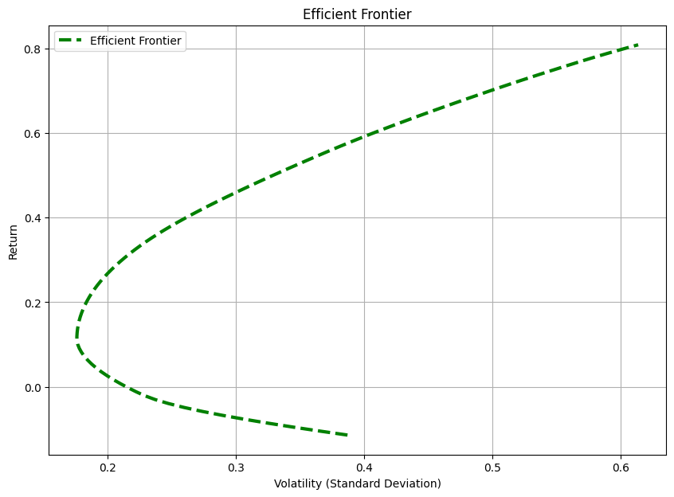

```python
plt.figure(figsize=(10, 7))
plt.plot(efficient_frontier_volatility, target_returns[:len(efficient_frontier_volatility)], 'g--', linewidth=3, label='Efficient Frontier')
#plt.scatter(optimal_risk,optimal_return)
plt.title('Efficient Frontier')
plt.xlabel('Volatility (Standard Deviation)')
plt.ylabel('Return')
plt.legend()
plt.grid(True)
plt.show()
```

### Step 4: Adding Risk-Free Asset + Market Portfolio + Capital Market Line

- For simplicity, let's just assume risk-free-rate is 0.04

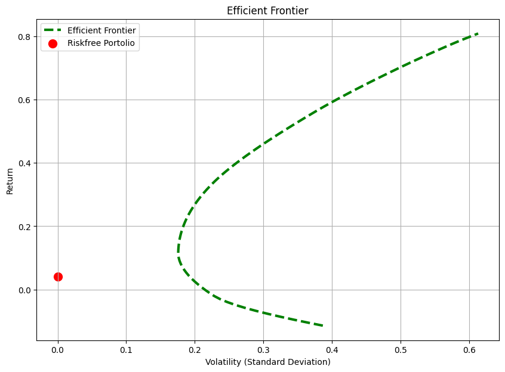

```python
risk_free_rate =  0.04  # Annual risk-free rate

plt.figure(figsize=(10, 7))
plt.plot(efficient_frontier_volatility, target_returns[:len(efficient_frontier_volatility)], 'g--', linewidth=3, label='Efficient Frontier')
#plt.scatter(optimal_risk,optimal_return)
plt.scatter(0, risk_free_rate, color='red', s=100, marker='o', label='Riskfree Portolio')

plt.title('Efficient Frontier')
plt.xlabel('Volatility (Standard Deviation)')
plt.ylabel('Return')
plt.legend()
plt.grid(True)
plt.show()
```

##### Step 4a. Market Portfolio:

- Maximize the **Sharpe Ratio**: This ratio measures the excess return relative to the risk (volatility).
- In the code, we minimize the **negative Sharpe ratio** because optimizers minimize by default.

```python
# Define the function to minimize (negative Sharpe ratio)
def neg_sharpe_ratio(weights, risk_free_rate):
    portfolio_ann_return = portfolio_return(weights,mean_returns)
    portfolio_ann_volatility = portfolio_risk(weights,cov_matrix)
    sharpe_ratio = (portfolio_ann_return - risk_free_rate) / portfolio_ann_volatility
    return -sharpe_ratio  # Minimize the negative Sharpe ratio



constraints = [
    {'type': 'eq', 'fun': constraint_sum_to_1},  # Sum of weights = 1
   # {'type': 'eq', 'fun': lambda w: constraint_return_eq_target_return(w, return_target)}  # Portfolio return = target return
]


result = optimize.minimize(fun=neg_sharpe_ratio,x0=initial_guess,args=(risk_free_rate,),constraints=constraints,bounds=bounds)
```

```python
optimal_weights = result.x
market_portfolio_return = portfolio_return(optimal_weights, mean_returns)
market_portfolio_volatility = portfolio_risk(optimal_weights,cov_matrix)
max_sharpe_ratio = -result.fun  # Since we minimized the negative Sharpe ratio
```

#### Step 4b: Define Capital Market Line

- Line from risk-free rate going throw market portfolio
- Also tangent to efficient frontier.

```python
cml_volatility = np.linspace(0, market_portfolio_volatility*2, 100)
cml_returns = risk_free_rate + (market_portfolio_return - risk_free_rate) * (cml_volatility / market_portfolio_volatility)
```

[figure not shown]

```python
import matplotlib.pyplot as plt

risk_free_rate = 0.04  # Annual risk-free rate

# Create the plot
plt.figure(figsize=(10, 7))

# Plot Efficient Frontier
plt.plot(efficient_frontier_volatility, target_returns[:len(efficient_frontier_volatility)], 'g--', linewidth=3, label='Efficient Frontier')

# Mark and label Risk-Free Portfolio
plt.scatter(0, risk_free_rate, color='red', s=100, marker='o', label='Risk-Free Portfolio')
plt.annotate('Risk-Free Portfolio',
             xy=(0, risk_free_rate),
             xytext=(0.02, risk_free_rate + 0.02),
             arrowprops=dict(arrowstyle="->", color='red'),
             color='red')

# Mark and label Market Portfolio
plt.scatter(market_portfolio_volatility, market_portfolio_return, color='red', s=100, marker='o', label='Market Portfolio')
plt.annotate('Market Portfolio',
             xy=(market_portfolio_volatility, market_portfolio_return),
             xytext=(market_portfolio_volatility + 0.03, market_portfolio_return + 0.02),
             arrowprops=dict(arrowstyle="->", color='red'),
             color='red')

# Plot Capital Market Line (CML)
#plt.plot(cml_volatility, cml_returns, 'b-', linewidth=2, label='Capital Market Line (CML)')

# Add title and labels
plt.title('Efficient Frontier with Capital Market Line (CML)')
plt.xlabel('Volatility (Standard Deviation)')
plt.ylabel('Return')
plt.legend()
plt.grid(True)
plt.show()
```

#### Step 4c: Add the Capital Market Line to Plot

```python
cml_volatility = np.linspace(0, market_portfolio_volatility*2, 100)
cml_returns = risk_free_rate + (market_portfolio_return - risk_free_rate) * (cml_volatility / market_portfolio_volatility)
```

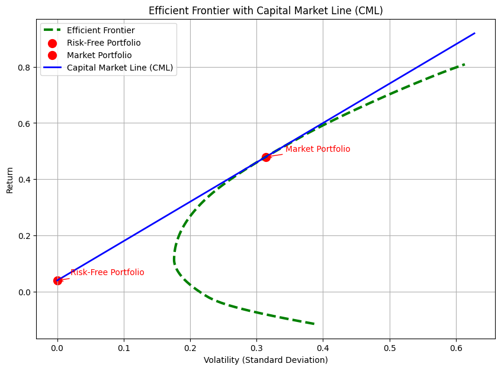

```python
import matplotlib.pyplot as plt

risk_free_rate = 0.04  # Annual risk-free rate

# Create the plot
plt.figure(figsize=(10, 7))

# Plot Efficient Frontier
plt.plot(efficient_frontier_volatility, target_returns[:len(efficient_frontier_volatility)], 'g--', linewidth=3, label='Efficient Frontier')

# Mark and label Risk-Free Portfolio
plt.scatter(0, risk_free_rate, color='red', s=100, marker='o', label='Risk-Free Portfolio')
plt.annotate('Risk-Free Portfolio',
             xy=(0, risk_free_rate),
             xytext=(0.02, risk_free_rate + 0.02),
             arrowprops=dict(arrowstyle="->", color='red'),
             color='red')

# Mark and label Market Portfolio
plt.scatter(market_portfolio_volatility, market_portfolio_return, color='red', s=100, marker='o', label='Market Portfolio')
plt.annotate('Market Portfolio',
             xy=(market_portfolio_volatility, market_portfolio_return),
             xytext=(market_portfolio_volatility + 0.03, market_portfolio_return + 0.02),
             arrowprops=dict(arrowstyle="->", color='red'),
             color='red')

# Plot Capital Market Line (CML)
plt.plot(cml_volatility, cml_returns, 'b-', linewidth=2, label='Capital Market Line (CML)')

# Add title and labels
plt.title('Efficient Frontier with Capital Market Line (CML)')
plt.xlabel('Volatility (Standard Deviation)')
plt.ylabel('Return')
plt.legend()
plt.grid(True)
plt.show()
```

#### Step 4d: Optional: Make plot nice, add random portfolios, and add anotations

```python
eff_idx=95
cml_idx=30
```

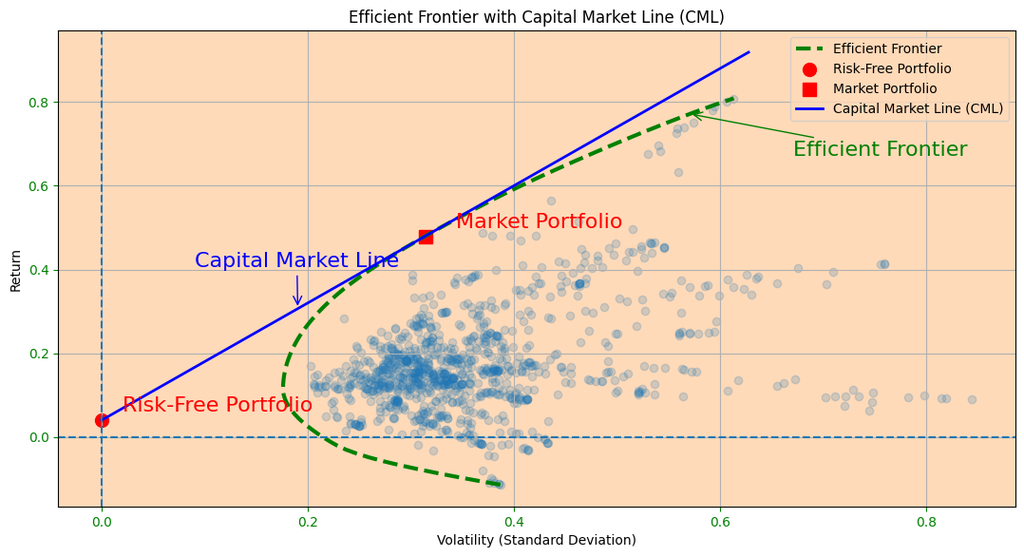

```python
import matplotlib.pyplot as plt
import matplotlib.pyplot as plt
plt.rcParams['axes.facecolor'] = 'peachpuff'
risk_free_rate = 0.04  # Annual risk-free rate

# Create the plot
plt.figure(figsize=(13, 6.5))

# Plot Efficient Frontier
plt.plot(efficient_frontier_volatility, target_returns[:len(efficient_frontier_volatility)], 'g--', linewidth=3, label='Efficient Frontier')
plt.scatter(random_vols,random_returns,alpha=0.2)

# Annotate the Efficient Frontier with an arrow pointing to a specific point
plt.annotate('Efficient Frontier',
             xy=(efficient_frontier_volatility[eff_idx], target_returns[eff_idx]),
             xytext=(efficient_frontier_volatility[eff_idx] + 0.1, target_returns[eff_idx] - 0.1),
             arrowprops=dict(arrowstyle="->", color='green'),
             color='green',fontsize=16)

plt.annotate('Capital Market Line',
             xy=(cml_volatility[cml_idx], cml_returns[cml_idx]),
             xytext=(cml_volatility[cml_idx] - 0.1, cml_returns[cml_idx] + 0.1),
             arrowprops=dict(arrowstyle="->", color='blue'),
             color='blue',fontsize=16)



# Mark and label Risk-Free Portfolio
plt.scatter(0, risk_free_rate, color='red', s=100, marker='o', label='Risk-Free Portfolio')
plt.annotate('Risk-Free Portfolio',
             xy=(0, risk_free_rate),
             xytext=(0.02, risk_free_rate + 0.02),
             #arrowprops=dict(arrowstyle="->", color='red'),
             color='red',fontsize=16)


# Mark and label Market Portfolio
plt.scatter(market_portfolio_volatility, market_portfolio_return, color='red', s=100, marker='s', label='Market Portfolio')
plt.annotate('Market Portfolio',
             xy=(market_portfolio_volatility, market_portfolio_return),
             xytext=(market_portfolio_volatility + 0.03, market_portfolio_return + 0.02),
             #arrowprops=dict(arrowstyle="->", color='red'),
             color='red',fontsize=16)

plt.tick_params(color='green', labelcolor='green')
#plt.scatter(random_vols,random_returns)
# Plot Capital Market Line (CML)
plt.plot(cml_volatility, cml_returns, 'b-', linewidth=2, label='Capital Market Line (CML)')

plt.axhline(y=0,ls='--')
plt.axvline(x=0,ls='--')

# Add title and labels
plt.title('Efficient Frontier with Capital Market Line (CML)')
plt.xlabel('Volatility (Standard Deviation)')
plt.ylabel('Return')
plt.legend()
plt.grid(True)
plt.show()
```